# Survival Analysis in R

15/05/2019

## Who am I?

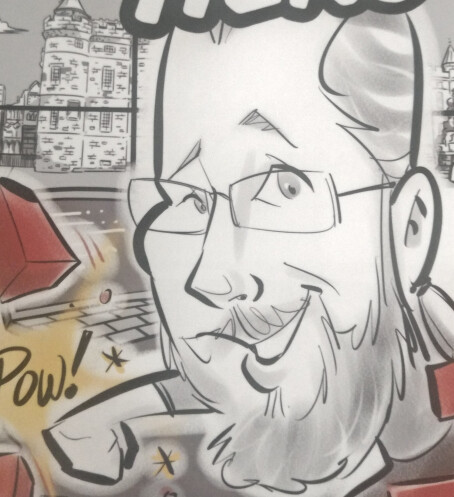

- History:
  - (Ex) Physicist
  - (Ex) System Administrator
  - (Ex) Software Developer
  - (Ex) FOSS Community Manager
  - Data scientist (~1 year)
    - **Caveat Emptor!**
- Contact:
  - https://emeraldreverie.org
  - https://fosstodon.org/@gwmngilfen
  - mailto:gsutclif@redhat.com

## Time-to-event data

- A study about cancer recurrance
- Time is recurrance-free time in days
- An “event” is the cancer recurring (triangle)
- Otherwise the patient gets a “censored” marker (circle) when they leave the study
- Also applies to *any* other time-to-event data
  - Unemployment duration
  - Failure times in equipment, etc.

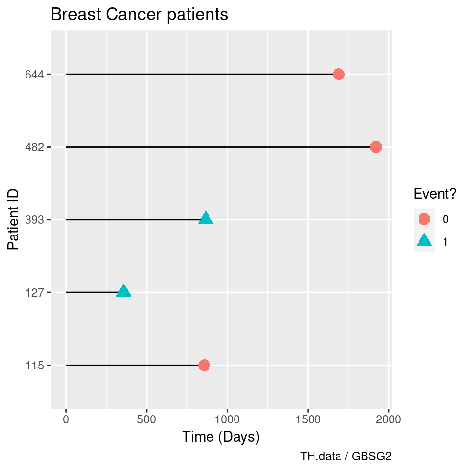

## So, about that mean…

- Characterizing censored data is hard
  - Averages operate on a vector of numbers
  - So what do we do with the censored ones?
  - Use them? Extend them? NA them?

```r
print(small_data)
```

```
##   rowid time cens start
## 1   127  357    1     0
## 2   482 1922    0     0
## 3   393  867    1     0
## 4   115  857    0     0
## 5   644 1692    0     0
```

```r
mean(c(357,1922,867,857,1692))
```

```
## [1] 1139
```

```r
mean(c(357,NA,867,NA,NA),na.rm = T)
```

```
## [1] 612
```

## Survival Analysis to the rescue

- What is the probability that a breast cancer patient survives longer than 5 years?
- What is the typical waiting time for a cab?
- Out of 100 unemployed people, how many do we expect to have a job again after 2 months?

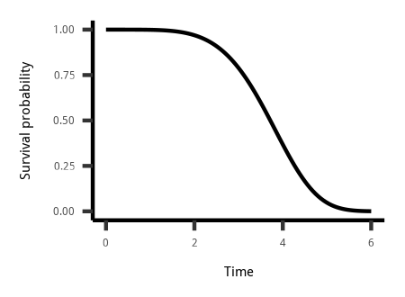

**Theory**

\[ S(t) = 1 - F(t) = P(T > t) \]

**Interpretation**

Probability that duration is greater than \(t\)

## Survival functions

**Median**:

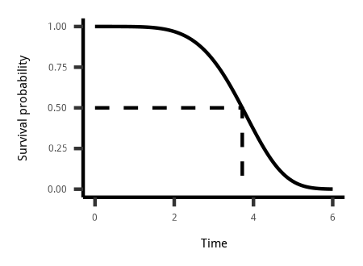

The median duration is t.

**Proportion at time \(t\)**:

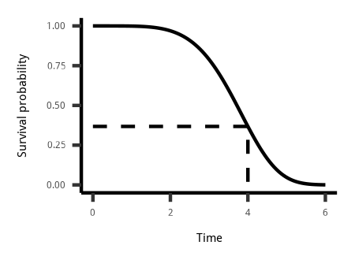

\(100 \cdot \hat S(t)\) percent of durations are longer than t.

## Estimating the survival function

[figure not shown]

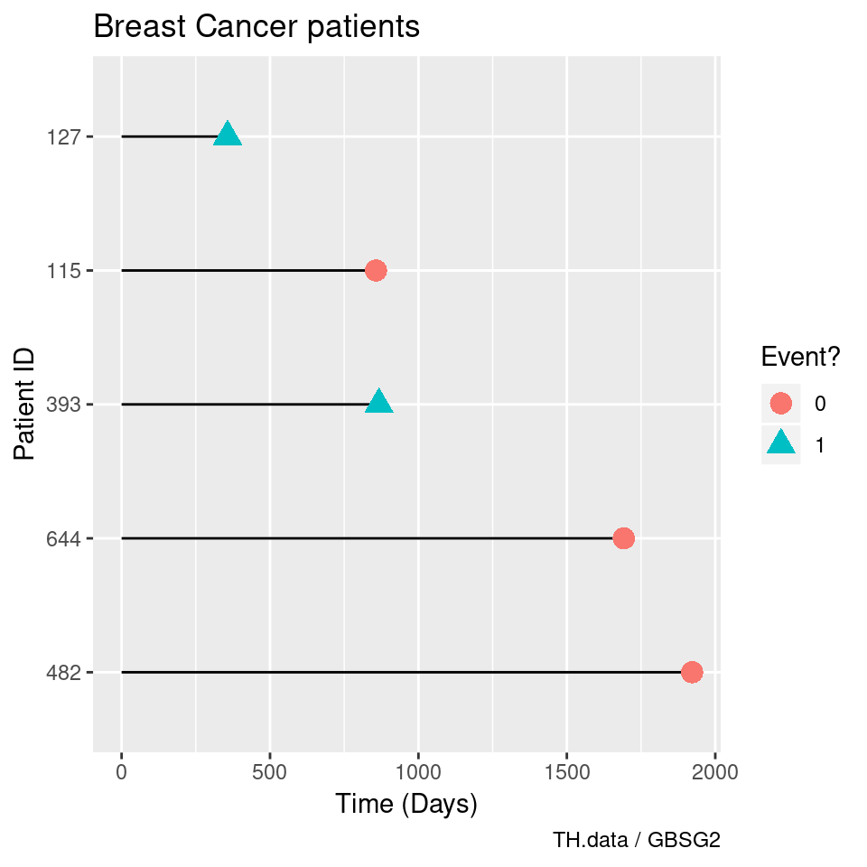

## The Kaplan-Meier estimate

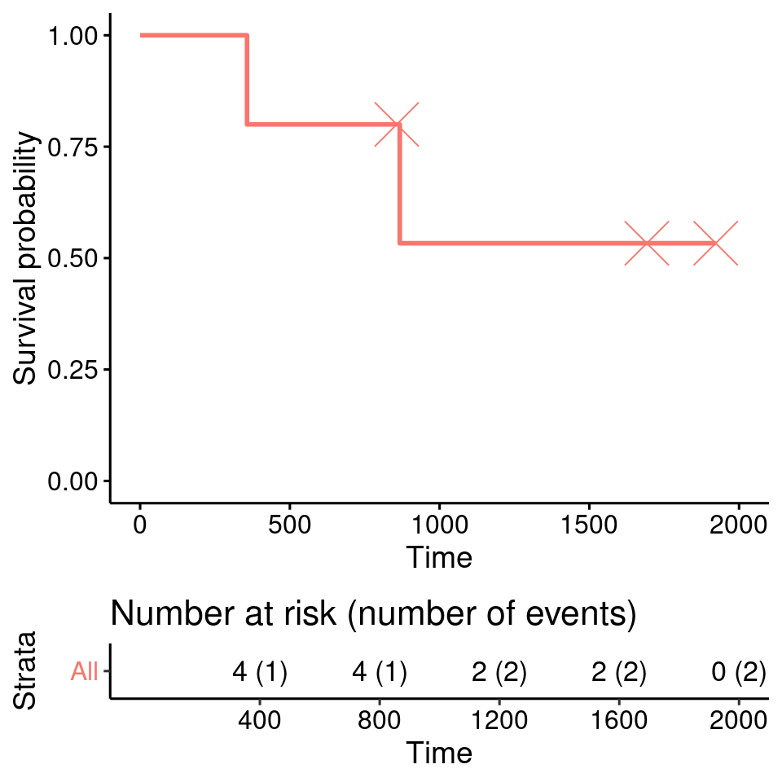

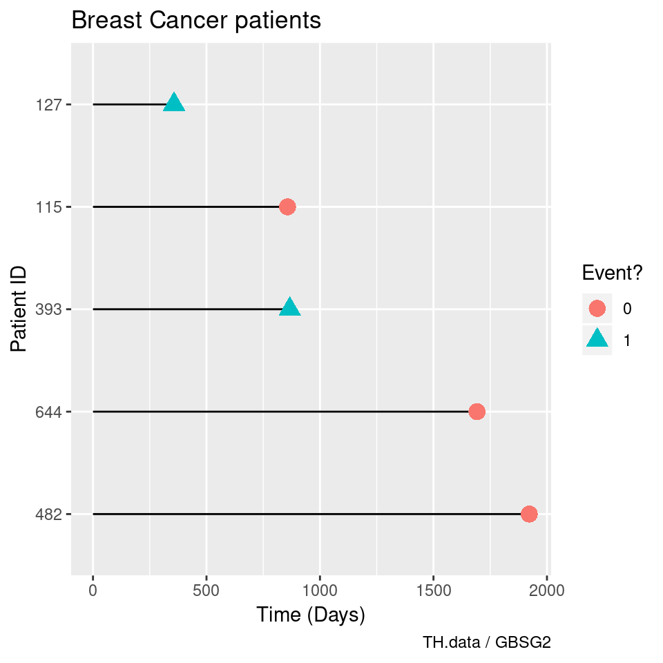

## The Kaplan-Meier estimate (code)

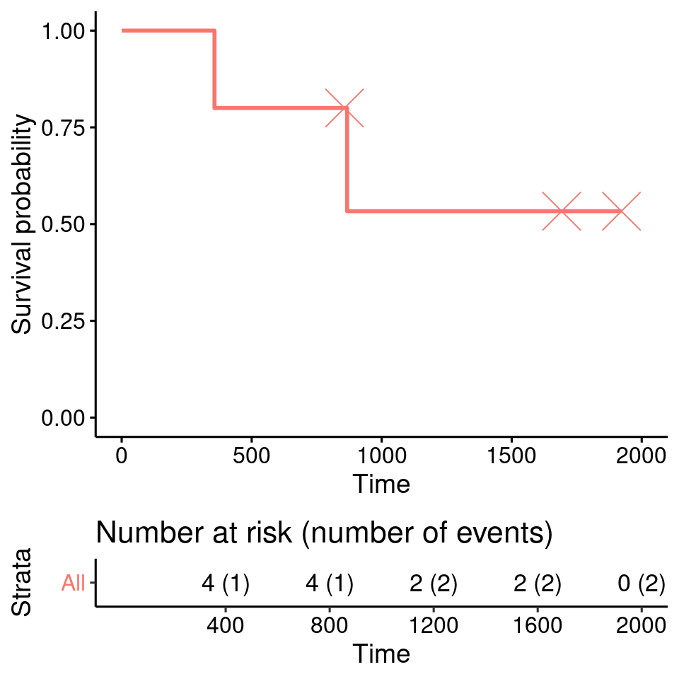

```r
km <- survfit(Surv(time,cens) ~ 1,
              data=small_data)

ggsurvplot(km,conf.int = F,
           censor.shape = 4,
           censor.size = 9,
           risk.table = 'nrisk_cumevents',
           legend = 'none')
```

**Formal Definition** \[ \hat S(t) = \prod_{i: t_i < t} \frac{n_i - d_i}{n_i} \]

## Kaplan-Meier (whole dataset)

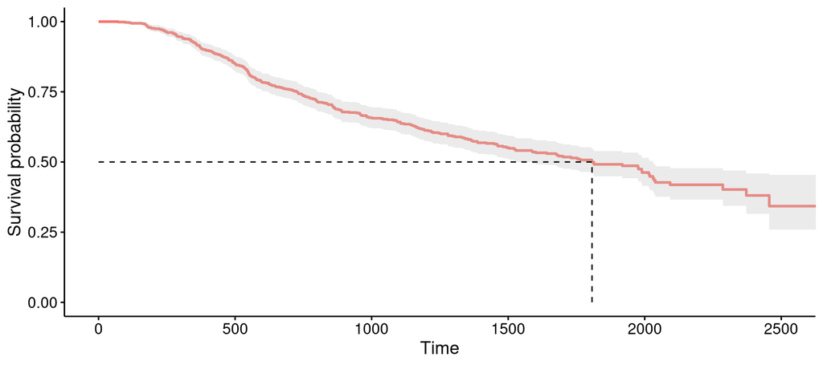

```r
km <- survfit(Surv(time,cens) ~ 1, data = GBSG2)
ggsurvplot(km, censor = F, conf.int = T, surv.median.line = 'hv', legend = 'none')
```

## Modelling on factors

```r
km <- survfit(
  Surv(time,cens) ~ 1,
  data = GBSG2)
```

## Modelling on factors

## Modelling on factors

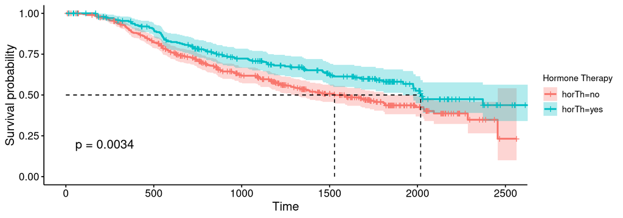

```r
km <- survfit(Surv(time, cens) ~ horTh, data = GBSG2)
ggsurvplot(km, data = GBSG2, surv.median.line = "hv",
           legend.title = "Hormone Therapy", legend = 'right',
           pval = TRUE, conf.int = TRUE
)
```

## Things we haven’t covered

- Weibull model
  - Smooth function, better for point predictions
  - Tricky to graph (need to fake-out a data frame)

```r
wb=survreg(Surv(time, cens)~horTh, GBSG2)
predict(wb, type = "quantile",
        p = 1 - 0.9,
        newdata = data.frame(
          horTh='yes'))
```

```
##        1
## 475.1155
```

- Cox Proportional Hazards model
  - Step function like KM
  - Takes the values of the covariate(s) into account
  - Basically same as KM for binary covariates

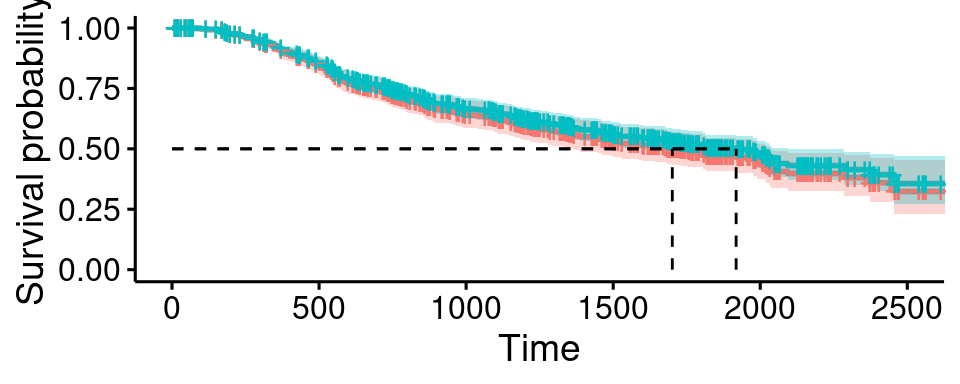

## Example 1 - Code Complexity vs Merge Time

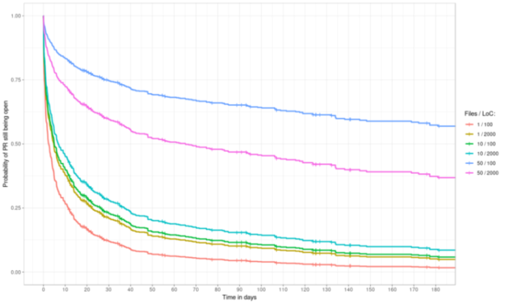

[Original Blog Post](https://theforeman.org/2019/03/merge-time-review-complexity.html)

Good for CI and comparative plots across predictors

## Example 2 - Merge times in parts of a codebase

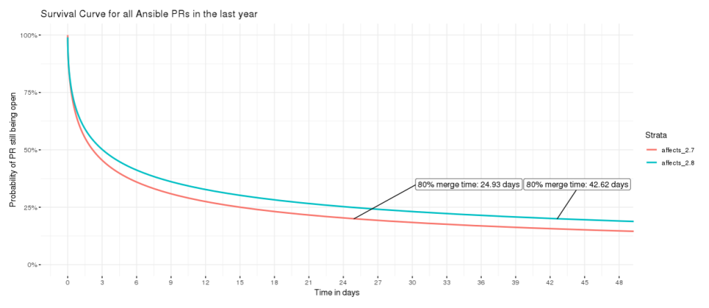

[Shiny App](https://stats.eng.ansible.com/apps/mergetimes/)

[figure not shown]

### Thanks!

### Questions?

- Comments
- Corrections
- Future ideas

### Contact

- https://emeraldreverie.org
- https://fosstodon.org/@gwmngilfen
- mailto:gsutclif@redhat.com